# Advertising Data

## Imports

```python
import pandas as pd
import matplotlib.pyplot as plt
import numpy as np
# this allows plots to appear directly in the notebook
%matplotlib inline
```

**What are the features?**

**TV:** advertising dollars spent on TV for a single product in a given market (in thousands of dollars)

**Radio:** advertising dollars spent on Radio

**Newspaper:** advertising dollars spent on Newspaper

**What is the response?**

**Sales:** sales of a single product in a given market (in thousands of widgets)

```python
# read data into a DataFrame
data = pd.read_csv('http://www-bcf.usc.edu/~gareth/ISL/Advertising.csv', index_col=0)
data.head()
```

|  | TV | Radio | Newspaper | Sales |
| --- | --- | --- | --- | --- |
| 1 | 230.1 | 37.8 | 69.2 | 22.1 |
| 2 | 44.5 | 39.3 | 45.1 | 10.4 |
| 3 | 17.2 | 45.9 | 69.3 | 9.3 |
| 4 | 151.5 | 41.3 | 58.5 | 18.5 |
| 5 | 180.8 | 10.8 | 58.4 | 12.9 |

```python
print np.shape(data)
```

```
(200, 4)
```

```python
# create X and y
feature_cols = ['TV', 'Radio', 'Newspaper']
X = data[feature_cols]
y = data.Sales

# follow the usual sklearn pattern: import, instantiate, fit
from sklearn.linear_model import LinearRegression
lm = LinearRegression()
lm.fit(X, y)

# print intercept and coefficients
print lm.intercept_
print lm.coef_
```

```
2.93888936946
[ 0.04576465  0.18853002 -0.00103749]
```

## Handling Categorical Predictors with Two Categories

Up to now, all of our predictors have been numeric. What if one of our predictors was categorical?

Let's create a new feature called Size, and randomly assign observations to be small or large:

```python
import numpy as np

# set a seed for reproducibility
np.random.seed(12345)

# create a Series of booleans in which roughly half are True
nums = np.random.rand(len(data))
mask_large = nums > 0.5

# initially set Size to small, then change roughly half to be large
data['Size'] = 'small'
data.loc[mask_large, 'Size'] = 'large'
data.head()
```

|  | TV | Radio | Newspaper | Sales | Size |
| --- | --- | --- | --- | --- | --- |
| 1 | 230.1 | 37.8 | 69.2 | 22.1 | large |
| 2 | 44.5 | 39.3 | 45.1 | 10.4 | small |
| 3 | 17.2 | 45.9 | 69.3 | 9.3 | small |
| 4 | 151.5 | 41.3 | 58.5 | 18.5 | small |
| 5 | 180.8 | 10.8 | 58.4 | 12.9 | large |

For scikit-learn, we need to represent all data numerically. If the feature only has two categories, we can simply create a dummy variable that represents the categories as a binary value:

```python
# create a new Series called IsLarge
data['IsLarge'] = data.Size.map({'small':0, 'large':1})
data.head()
```

|  | TV | Radio | Newspaper | Sales | Size | IsLarge |
| --- | --- | --- | --- | --- | --- | --- |
| 1 | 230.1 | 37.8 | 69.2 | 22.1 | large | 1 |
| 2 | 44.5 | 39.3 | 45.1 | 10.4 | small | 0 |
| 3 | 17.2 | 45.9 | 69.3 | 9.3 | small | 0 |
| 4 | 151.5 | 41.3 | 58.5 | 18.5 | small | 0 |
| 5 | 180.8 | 10.8 | 58.4 | 12.9 | large | 1 |

```python
# create X and y
feature_cols = ['TV', 'Radio', 'Newspaper', 'IsLarge']
X = data[feature_cols]
y = data.Sales

# instantiate, fit
lm = LinearRegression()
lm.fit(X, y)

# print coefficients
zip(feature_cols, lm.coef_)
```

```
[('TV', 0.045719820924362775),
 ('Radio', 0.18872814313427869),
 ('Newspaper', -0.0010976794483516079),
 ('IsLarge', 0.0574238508548277)]
```

## Handling Categorical Predictors with More than Two Categories

Let's create a new feature called Area, and randomly assign observations to be rural, suburban, or urban:

```python
# set a seed for reproducibility
np.random.seed(123456)

# assign roughly one third of observations to each group
nums = np.random.rand(len(data))
mask_suburban = (nums > 0.33) & (nums < 0.66)
mask_urban = nums > 0.66
data['Area'] = 'rural'
data.loc[mask_suburban, 'Area'] = 'suburban'
data.loc[mask_urban, 'Area'] = 'urban'
data.head()
```

|  | TV | Radio | Newspaper | Sales | Size | IsLarge | Area |
| --- | --- | --- | --- | --- | --- | --- | --- |
| 1 | 230.1 | 37.8 | 69.2 | 22.1 | large | 1 | rural |
| 2 | 44.5 | 39.3 | 45.1 | 10.4 | small | 0 | urban |
| 3 | 17.2 | 45.9 | 69.3 | 9.3 | small | 0 | rural |
| 4 | 151.5 | 41.3 | 58.5 | 18.5 | small | 0 | urban |
| 5 | 180.8 | 10.8 | 58.4 | 12.9 | large | 1 | suburban |

We have to represent Area numerically, but we can't simply code it as 0=rural, 1=suburban, 2=urban because that would imply an ordered relationship between suburban and urban (and thus urban is somehow "twice" the suburban category). Instead, we create another dummy variable:

```python
# create three dummy variables using get_dummies, then exclude the first dummy column
area_dummies = pd.get_dummies(data.Area, prefix='Area').iloc[:, 1:]

# concatenate the dummy variable columns onto the original DataFrame (axis=0 means rows, axis=1 means columns)
data = pd.concat([data, area_dummies], axis=1)
data.head()
```

|  | TV | Radio | Newspaper | Sales | Size | IsLarge | Area | Area_suburban | Area_urban |
| --- | --- | --- | --- | --- | --- | --- | --- | --- | --- |
| 1 | 230.1 | 37.8 | 69.2 | 22.1 | large | 1 | rural | 0.0 | 0.0 |
| 2 | 44.5 | 39.3 | 45.1 | 10.4 | small | 0 | urban | 0.0 | 1.0 |
| 3 | 17.2 | 45.9 | 69.3 | 9.3 | small | 0 | rural | 0.0 | 0.0 |
| 4 | 151.5 | 41.3 | 58.5 | 18.5 | small | 0 | urban | 0.0 | 1.0 |
| 5 | 180.8 | 10.8 | 58.4 | 12.9 | large | 1 | suburban | 1.0 | 0.0 |

```python
# create X and y
feature_cols = ['TV', 'Radio', 'Newspaper', 'IsLarge', 'Area_suburban', 'Area_urban']
X = data[feature_cols]
y = data.Sales

# instantiate, fit
lm = LinearRegression()
lm.fit(X, y)

# print coefficients
zip(feature_cols, lm.coef_)
```

```
[('TV', 0.045744010363313749),
 ('Radio', 0.18786669552525811),
 ('Newspaper', -0.0010876977267108138),
 ('IsLarge', 0.077396607497479092),
 ('Area_suburban', -0.10656299015958638),
 ('Area_urban', 0.26813802165220063)]
```

```python
# create three dummy variables using get_dummies, then exclude the first dummy column
area_dummies = pd.get_dummies(data.Area, prefix='Area').iloc[:, 1:]

# concatenate the dummy variable columns onto the original DataFrame (axis=0 means rows, axis=1 means columns)
data = pd.concat([data, area_dummies], axis=1)
data.head()
```

|  | TV | Radio | Newspaper | Sales | Size | IsLarge | Area | Area_suburban | Area_urban | Area_suburban | Area_urban |
| --- | --- | --- | --- | --- | --- | --- | --- | --- | --- | --- | --- |
| 1 | 230.1 | 37.8 | 69.2 | 22.1 | large | 1 | rural | 0.0 | 0.0 | 0.0 | 0.0 |
| 2 | 44.5 | 39.3 | 45.1 | 10.4 | small | 0 | urban | 0.0 | 1.0 | 0.0 | 1.0 |
| 3 | 17.2 | 45.9 | 69.3 | 9.3 | small | 0 | rural | 0.0 | 0.0 | 0.0 | 0.0 |
| 4 | 151.5 | 41.3 | 58.5 | 18.5 | small | 0 | urban | 0.0 | 1.0 | 0.0 | 1.0 |
| 5 | 180.8 | 10.8 | 58.4 | 12.9 | large | 1 | suburban | 1.0 | 0.0 | 1.0 | 0.0 |

```python
# create X and y
feature_cols = ['TV', 'Radio', 'Newspaper', 'IsLarge', 'Area_suburban', 'Area_urban']
X = data[feature_cols]
y = data.Sales

# instantiate, fit
lm = LinearRegression()
lm.fit(X, y)

# print coefficients
zip(feature_cols, lm.coef_)
```

```
[('TV', 0.045744010363313783),
 ('Radio', 0.1878666955252597),
 ('Newspaper', -0.0010876977267114364),
 ('IsLarge', 0.077396607497479467),
 ('Area_suburban', -0.053281495079793351),
 ('Area_urban', -0.053281495079793323)]
```

## What Didn't We Cover?

Detecting collinearity

Diagnosing model fit

Transforming predictors to fit non-linear relationships

Interaction terms

Assumptions of linear regression

```python
print lm.score(X,y)
```

```
0.898161187539
```

```
[[  7.0658692 ]
 [ 21.12245377]]
```

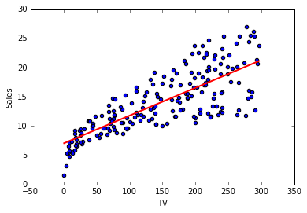

```python
X_new = pd.DataFrame({'TV': [data.TV.min(), data.TV.max()]})
#X_new.head()

# make predictions for those x values and store them
X = data[['TV']]
y = data[['Sales']]
# instantiate, fit
lm = LinearRegression()
lm.fit(X, y)
preds = lm.predict(X_new)
print preds
# first, plot the observed data
data.plot(kind='scatter', x='TV', y='Sales')

# then, plot the least squares line
plt.plot(X_new, preds, c='red', linewidth=2)
```